# Annotation plots with smallCAGEqc

Charles Plessy

2016-08-31

# R commands

The main command to produce annotation plots in *smallCAGEqc* is called `plotAnnot`. It takes a table containing the sample metadata, a *scope*, a title and optionally a factor to group similar plots together.

The *scope* determines what data is plotted and how it is normalised. The available scopes will be explained with an example plot in a later part of this document, but first, let’s see the input in more details.

Here, we will use some of the example data that is distributed in *smallCAGEqc*. The commands below load the R package and load the example data in a data frame called `libs`.

```r
library(smallCAGEqc)
libs <- read.table(system.file("extdata/libs-with-all-metadata.tsv", package="smallCAGEqc"))
```

## Sample metadata

The following columns in the metadata table describe the total remaining pairs step after step in the processing.

- **total**: The total number of pairs before tag extraction (called “raw” in some other pipelines). In cases where this number is not available per sample, for example when demultiplexing and tag extraction are performed at the same stage, it is set arbitrarily to zero.
- **extracted**: The number of pairs where the linkers and unique molecular identifier (if present) were successfully extracted.
- **cleaned**: The number of pairs remaining after filtering out spike, rRNA, low-complexity, primer artefact and other unwanted sequences.
- **mapped**: The number of pairs with at least one successful alignment. This called “genome_mapped” in some other pipelines.
- **properpairs**: The number or pair remaining after filtering out the non-proper alignments. This is called “properly_mapped” in some other pipelines.
- **counts**: The number of unique molecules counted after alignment. This is called “transcript_count” in some other pipelines.

The following columns describe the number of pairs removed at some step of the processing.

- **spikes**, **rdna**: The number of pairs removed because they matched spikes or rRNA reference sequences, respectively.
- **tagdust**: The number of pairs removed because of low-complexity or similarity to primer artefacts.

The following columns describe the number of TSS (after proper pairing and deduplication) aligning to known regions in the genome.

- **promoter**: Promoter regions.
- **exon**: Known exons.
- **intron**: Know introns (that is: the TSS matches a transcript but none of its exons).
- **unknown**: None of the above; basically intergenic.
- **other**: Normally there should not be anything in this category since *unknown* should catch all intergenic TSS. But sometimes there is a misdesign, for instance in the example data here, the annotation file contained one more category, “boundary”, which was not handled correctly by smallCAGEqc.

The annotation is hierarchical (promoters have priority on exons, etc.), so the sum of the annotation columns above should be be equal to the *counts* column.

# Different types of scopes

## Step-by-step extraction

Shows how many pairs are removed by the extraction, cleaning, mapping (proper pairs) and transcript counting steps described above.

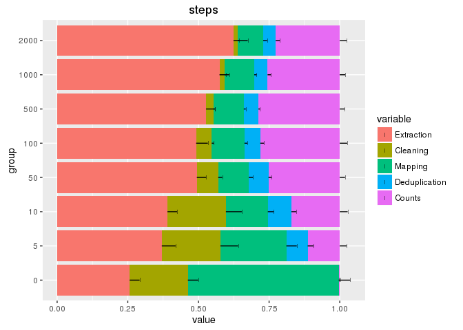

```r
plotAnnot(libs, "steps", "steps")
```

## QC report

Pairs are categorised as tag dust, rDNA, spikes, unmapped, non-proper, duplicates and counts, and normalised by the total number of extracted pairs. Non-extracted pairs are ignored.

Compared to “steps”, this scope gives more details on the sequences removed at the TagDust and mapping stages of the processing pipeline.

- **Tag_dust**, **rDNA**, **Spikes**: same numbers as in the *tagdust*, *rdna* and *spikes* columns of the metadata table.
- **Unmapped**: The number of pairs that could not be mapped.
- **Non_proper**: The number of pairs that did not have a *proper* alignment.
- **Duplicates**: The number of pairs that do not add a molecule count.
- **Counts**: same as in “steps”.

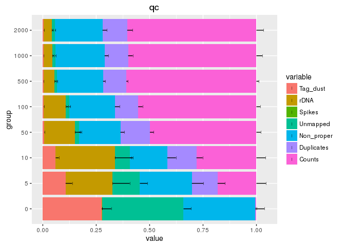

```r
plotAnnot(libs, "qc", "qc")
```

## Annotation of the transcript or tag counts

The unique molecule counts are grouped in annotation categories (“promoter”, “exon”, “intron” and “intergenic”), as described above.

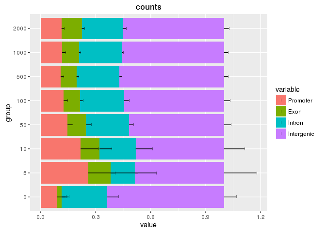

```r
plotAnnot(libs[libs$counts > 0,], "counts", "counts")
```

## Annotation of the mapped reads

Same as “counts”, with the addition of duplicates and non-proper pairs. Therefore the plot represents all the mapped data.

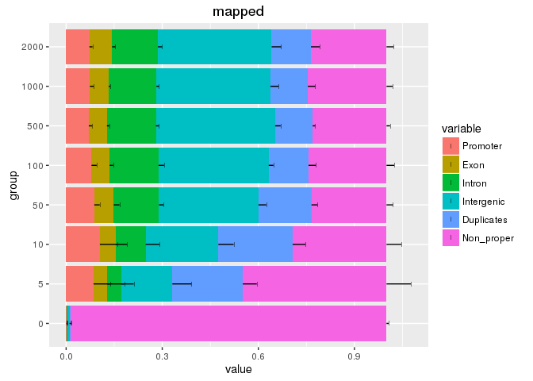

```r
plotAnnot(libs, "mapped", "mapped")
```

## QC including annotations

Pairs are categorised by extraction step and genome annotation.

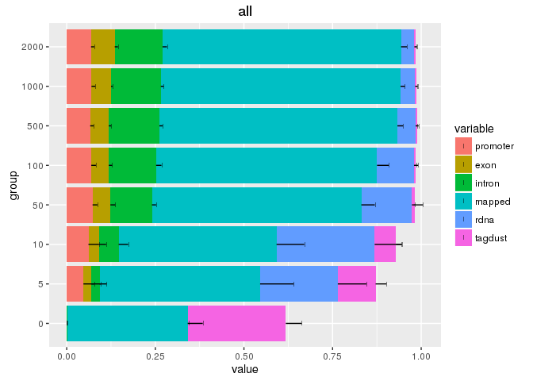

```r
plotAnnot(libs, "all", "all")
```

## Annotation, normalised by mapped reads

Same as `all` except that normalisation is relative to the number of mapped reads

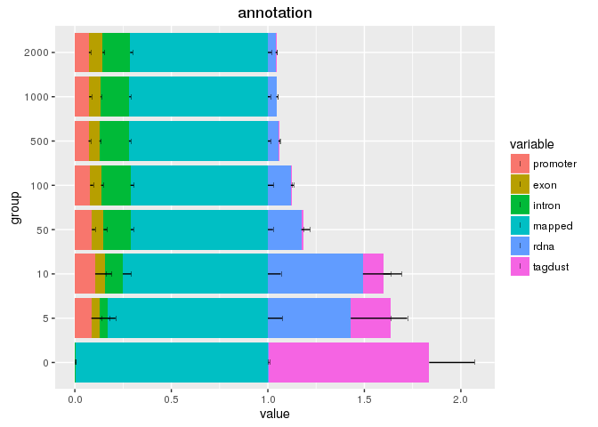

```r
plotAnnot(libs, "annotation", "annotation")
```

# Contents of the `libs` table

```r
libs
```

```
##     samplename sampleid  total extracted cleaned tagdust  rdna spikes
## A01        A01        1  57836     44740   33456   11244    40      0
## A02        A02        2  56608     42798   31358   11404    36      0
## A03        A03        3  79068     60769   49450   11283    36      0
## A04        A04        4  51895     37394   26998   10356    40      0
## A05        A05        5  62074     45786   34516   11239    31      0
## A06        A06        6  44003     29504   21978    7471    55      0
## A07        A07        7  60988     42773   28707   14026    40      0
## A08        A08        8  32950     23815   17276    6508    31      0
## A09        A09        9  28039     21889   15656    6163    70      0
## A10        A10       10  33938     24986   18511    6455    20      0
## A11        A11       11  31996     24512   16077    8352    83      0
## A12        A12       12  31146     24500   16029    8435    36      0
## B01        B01       13 113516     79890   47354    6246 26290      0
## B02        B02       14  72654     50406   31768    4061 14577      0
## B03        B03       15 106809     62736   50864    6573  5299      0
## B04        B04       16  80569     47843   34153    6099  7591      0
## B05        B05       17 107056     65211   48808    6118 10285      0
## B06        B06       18  79748     43397   30860    4525  8012      0
## B07        B07       19 110920     65635   51751    4582  9302      0
## B08        B08       20  66320     45432   28835    6448 10149      0
## B09        B09       21  95686     62955   40331    4706 17918      0
## B10        B10       22  55199     33872   18625    5643  9604      0
## B11        B11       23  48259     30849   21371    4268  5210      0
## B12        B12       24  72900     46406   26727    4635 15044      0
## C01        C01       25 149338     89401   49290    7319 32792      0
## C02        C02       26 138463     88758   63852    2770 22136      0
## C03        C03       27 129733     84172   49076    4081 31015      0
## C04        C04       28 110834     65837   49627    3515 12695      0
## C05        C05       29 143846     78132   53696    4636 19800      0
## C06        C06       30 109061     68825   38230    5636 24959      0
## C07        C07       31 119133     75078   44183    3683 27212      0
## C08        C08       32  78937     50912   33410    3141 14361      0
## C09        C09       33  92263     57695   35157    4207 18331      0
## C10        C10       34 104621     64239   47782    3627 12830      0
## C11        C11       35  77071     43272   31482    2827  8963      0
## C12        C12       36  75814     44190   34379    2762  7049      0
## D01        D01       37 211918    108057   93175     687 14195      0
## D02        D02       38 126215     72882   61995     446 10441      0
## D03        D03       39 141855     72767   59564     392 12811      0
```

[output cut: 236 more lines]

```
## G10 1772-087-069 2642 92.13822 1432   4437     1     1757   11524   636
## G11 1772-087-069 3136 93.63214 1756   4911     0     2883   11461   800
## G12 1772-087-069 3411 94.58613 1795   4978     3     2374   12528   869
## H01 1772-087-069 4296 92.15265 4700   9467     7     4900   23765   980
## H02 1772-087-069 3697 93.16116 3503   8810   119     4394   18020   863
## H03 1772-087-069 3260 92.42869 2731   5836     0     2818   14345   802
## H04 1772-087-069 3112 90.11942 3835   7867     1     4015   20135   684
## H05 1772-087-069 2847 88.82836 3141   5493     1     3349   17100   677
## H06 1772-087-069 2671 85.46402 3499   5371     1     2258   15094   601
## H07 1772-087-069 4125 89.92747 4114   7256     0     3854   21001   934
## H08 1772-087-069 3086 92.93838 2827   5158    24     2465   10809   844
## H09 1772-087-069 3581 93.04251 2007   3820     0     2580    9226   986
## H10 1772-087-069 2565 93.39395 1287   3116     0     1515    6596   700
## H11 1772-087-069 2491 90.60411 1498   3957     0     2038   10149   595
## H12 1772-087-069 2738 91.97103 2105   4229     0     1751   10407   637
```